# Artesunate vs. Quinine Dara Simulation

Background Quinine was the main drug used to treat malaria in Africa, South America, and Asia even though rates of mortality in cases of severe malaria remained high. There have been case studies showing treatment with artesunate to be more effective. Artesunate is also safer and easier to administer but there was still a question as to whether it reduced mortality more than quinine. A paper was published in 2006 that confirmed artesunate is more effective than quinine. Quinine was shown to be associated with hypoglycemia (meaning low blood sugar) and less effective against hyperparasitaemia (greater than 10% parasitaemia).

Creation of data set and code:

```r
library(dplyr)
set.seed(100)
logistic <- function(t) 1 / (1 + exp(-t))
simMortality<-function(N){
  severe_malaria<-sample(1:100, N, replace= TRUE)
  Hyperparasitaemia_artesunate<- runif(N)<.23*logistic((severe_malaria-20/10))
  Hyperparasitaemia_quinine<- runif(N)<.53*logistic((severe_malaria-20/10))
  Treatment_artesunate<- runif(N)<.15*logistic((severe_malaria-20/10))
  Treatment_quinine<- runif(N)<.22*logistic((severe_malaria-20/10))
  Death_within_48hr_artesunate<- runif(N)<.08*logistic((severe_malaria-20/10))
  Death_within_48hr_quinine<- runif(N)<.10*logistic((severe_malaria-20/10))
  Death_after_48hr_artesunate<- runif(N)<.06*logistic((severe_malaria-20/10))
  Death_after_48hr_quinine<- runif(N)<.12*logistic((severe_malaria-20/10))
  data.frame(severe_malaria,Hyperparasitaemia_artesunate, Hyperparasitaemia_quinine,   Treatment_artesunate, Treatment_quinine, Death_within_48hr_artesunate,               Death_within_48hr_quinine, Death_after_48hr_artesunate, Death_after_48hr_quinine)
}

mydata<-simMortality(1000)
summary(mydata)
```

```
##  severe_malaria   Hyperparasitaemia_artesunate Hyperparasitaemia_quinine
##  Min.   :  1.00   Mode :logical                Mode :logical
##  1st Qu.: 29.00   FALSE:774                    FALSE:484
##  Median : 52.00   TRUE :226                    TRUE :516
##  Mean   : 52.31   NA's :0                      NA's :0
##  3rd Qu.: 77.00
##  Max.   :100.00
##  Treatment_artesunate Treatment_quinine Death_within_48hr_artesunate
##  Mode :logical        Mode :logical     Mode :logical
##  FALSE:847            FALSE:769         FALSE:924
##  TRUE :153            TRUE :231         TRUE :76
##  NA's :0              NA's :0           NA's :0
##
##
##  Death_within_48hr_quinine Death_after_48hr_artesunate
##  Mode :logical             Mode :logical
##  FALSE:907                 FALSE:951
##  TRUE :93                  TRUE :49
##  NA's :0                   NA's :0
##
##
##  Death_after_48hr_quinine
##  Mode :logical
##  FALSE:886
##  TRUE :114
##  NA's :0
##
##
```

Here’s a pair plot.

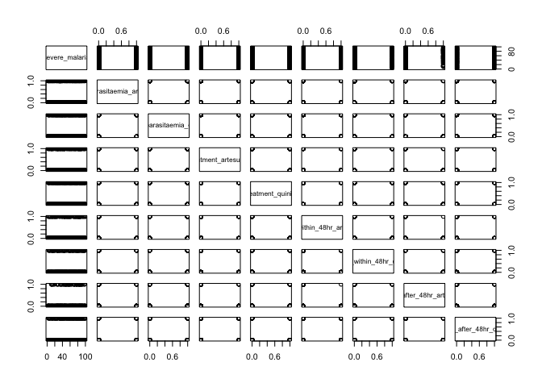

```r
plot(mydata)
```

```r
fit<- lm(severe_malaria~ Hyperparasitaemia_artesunate + Hyperparasitaemia_quinine + Treatment_artesunate + Treatment_quinine + Death_after_48hr_artesunate +Death_after_48hr_quinine, data = mydata)
summary(fit)
```

```
##
## Call:
## lm(formula = severe_malaria ~ Hyperparasitaemia_artesunate +
##     Hyperparasitaemia_quinine + Treatment_artesunate + Treatment_quinine +
##     Death_after_48hr_artesunate + Death_after_48hr_quinine, data = mydata)
##
## Residuals:
##    Min     1Q Median     3Q    Max
## -52.69 -23.01   0.13  25.10  52.87
##
## Coefficients:
##                                  Estimate Std. Error t value Pr(>|t|)
## (Intercept)                       50.0082     1.5743  31.765   <2e-16 ***
## Hyperparasitaemia_artesunateTRUE  -2.8793     2.1734  -1.325   0.1855
## Hyperparasitaemia_quinineTRUE      3.3521     1.8175   1.844   0.0654 .
## Treatment_artesunateTRUE           0.4984     2.5258   0.197   0.8436
## Treatment_quinineTRUE              1.6034     2.1582   0.743   0.4577
## Death_after_48hr_artesunateTRUE    5.6913     4.2155   1.350   0.1773
## Death_after_48hr_quinineTRUE       4.3276     2.8576   1.514   0.1302
## ---
## Signif. codes:  0 '***' 0.001 '**' 0.01 '*' 0.05 '.' 0.1 ' ' 1
##
## Residual standard error: 28.68 on 993 degrees of freedom
## Multiple R-squared:  0.01002,    Adjusted R-squared:  0.00404
## F-statistic: 1.675 on 6 and 993 DF,  p-value: 0.1238
```